# A covid-19-cel kapcsolatos megosztások időbeli modellezése

### Kutatási kérdések:

- Hogyan változott a covid-19 járvány alatt a webes tartalommegosztások száma?
- Hogyan függ össze tartalommegoszt a korházbakerülések számával?

```python
# Felhsznált modulok

from datetime import datetime
import numpy as np
import pandas as pd
from matplotlib import pyplot as plt
from statsmodels.graphics import tsaplots
from statsmodels.tsa.stattools import adfuller
from statsmodels import api as sm
import warnings
warnings.filterwarnings('ignore')

figsize = (15,10) # ábrákhoz
```

### Felhasznált adatbázis:

#### Covid 19-cel kapcsolatos magyar nyelvű tweeetek 2021-09-17 és 2022-04-09 között, melyekhez webes tartalom társult.

#### Elérhető: https://github.com/vetszabolcs/KRE_projekt/blob/main/databases/url_count.csv

```python
# Eredeti adatok
df = pd.read_csv("url_count.csv")
df
```

|  | Unnamed: 0 | date | count |
| --- | --- | --- | --- |
| 0 | 1 | 2021-09-17 | 1 |
| 1 | 2 | 2021-09-18 | 8 |
| 2 | 3 | 2021-09-19 | 19 |
| 3 | 4 | 2021-09-20 | 11 |
| 4 | 5 | 2021-09-21 | 11 |
| ... | ... | ... | ... |
| 170 | 171 | 2022-04-05 | 25 |
| 171 | 172 | 2022-04-06 | 13 |
| 172 | 173 | 2022-04-07 | 26 |
| 173 | 174 | 2022-04-08 | 23 |
| 174 | 175 | 2022-04-09 | 9 |

175 rows × 3 columns

#### Hiányzó napok imputálása, index oszlop törlése

```python
# Adat "wrangling"
df = df.iloc[:, 1:]
df["date"] = pd.to_datetime(df["date"])
df.index = pd.DatetimeIndex(df["date"])
df.drop("date", axis=1, inplace=True)
df_orig = df.copy()

df = df.reindex(pd.date_range("2021-09-17", "2022-04-09"), fill_value=pd.NA)
df.reset_index(inplace=True)
df.rename(columns={"index":"date"}, inplace=True)
df
```

|  | date | count |
| --- | --- | --- |
| 0 | 2021-09-17 | 1.0 |
| 1 | 2021-09-18 | 8.0 |
| 2 | 2021-09-19 | 19.0 |
| 3 | 2021-09-20 | 11.0 |
| 4 | 2021-09-21 | 11.0 |
| ... | ... | ... |
| 200 | 2022-04-05 | 25.0 |
| 201 | 2022-04-06 | 13.0 |
| 202 | 2022-04-07 | 26.0 |
| 203 | 2022-04-08 | 23.0 |
| 204 | 2022-04-09 | 9.0 |

205 rows × 2 columns

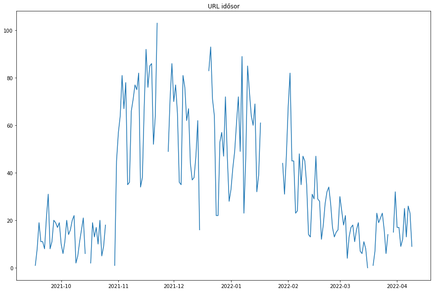

```python
# Eredeti idősor
plt.figure(figsize=figsize)
plt.plot(df["date"], df["count"])
plt.title("URL idősor")
plt.show()
```

### ANO (average nearest observation method)

Az idősor ábrája alapján nem mutatható ki egyértelmű szezonalitás, illetve a jövebi értékek előrejelzése nem célja a kutatásnak, így a hiányzó értékek kezelésére az ANO módszert alaklamztam (Huo et al., 2010).

- [96, 88, missing1, missing2, 140, 148]
- [96, 88, missing1=(88+140) / 2, missing2, 140, 148]
- [96, 88, missing1=(88+140) / 2, missing2=((88+140) / 2 + 140)/2, 140, 148]

```python
# ANO (average nearest observation method) implementálsa

for i, v in enumerate(df["count"]):
    if pd.isna(v):
        next_vals = df["count"][i:]
        first_ok = df["count"][next_vals.first_valid_index()]
        df["count"][i] = round((df["count"][i-1] + first_ok) / 2)

df.index = df["date"]
df.drop("date", axis=1, inplace=True)

print("Maradt-e missing:", df["count"].isna().any())
```

```
Maradt-e missing: False
```

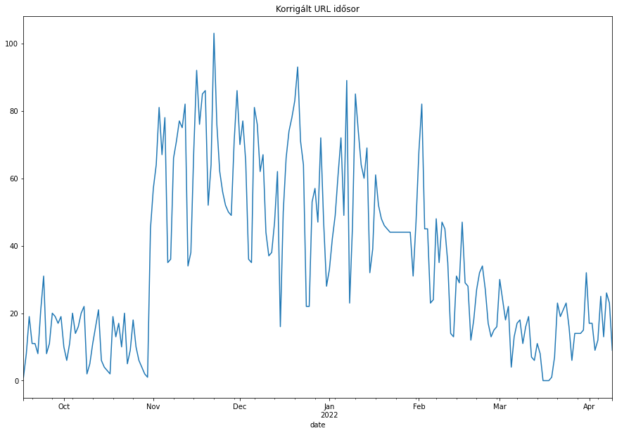

```python
# Korrigált idősor
df.plot(figsize=figsize, legend=False, title="Korrigált URL idősor")
plt.show()
```

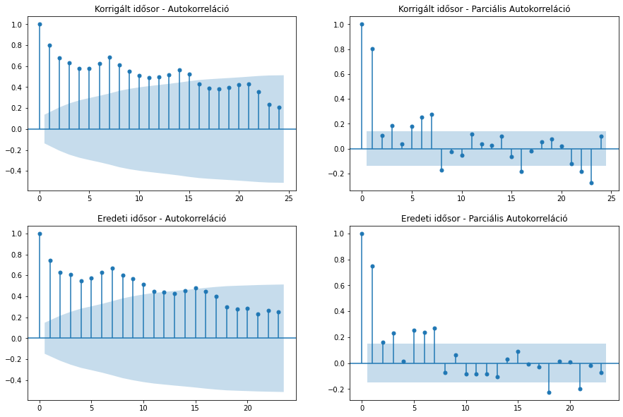

```python
# Korrelogrammok
fig, axes = plt.subplots(2,2, figsize=(15,10))

tsaplots.plot_acf(df, ax=axes[0,0], title="Korrigált idősor - Autokorreláció")
tsaplots.plot_pacf(df, ax=axes[0,1], title="Korrigált idősor - Parciális Autokorreláció")

tsaplots.plot_acf(df_orig, ax=axes[1,0], title="Eredeti idősor - Autokorreláció")
tsaplots.plot_pacf(df_orig, ax=axes[1,1], title="Eredeti idősor - Parciális Autokorreláció")
plt.show()
```

Az autokorreláció alapján jelentős mértékű összefüggés mutatható ki az idősor korábbi értékeivel - egészen 15-ös differenciálás mellett is szignifikánsak az értékek. Ez részben az ANO módszerrel történő adatimputálás eredménye. Az alsó ábrán az eredeti (hiányzó napokat tartalmazó) adatokra futtatott autokorrálciók láthatók. Ezesetben az autokorreláció valamivel kevesebb, legfeljebb 10-es lag mellett produkál szignifikáns értékeket. Egy hetes intervallumban mindkét esetben szignifikáns a parciális autkorreláció.

### Normalitásvizsgálat

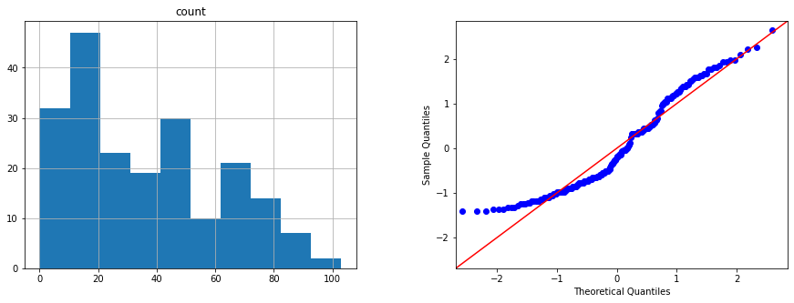

```python
# Imputált adatokat tartalmazó adatbázis
fig, axes = plt.subplots(1,2, figsize=(15,5))
df.hist(ax=axes[0])
sm.qqplot(df["count"], fit=True, line="45", ax=axes[1])
plt.show()
```

A histogram és a qq-plot alapján sem normális eloszlásból származik az idősor.

```python
# Lag = 1 differenciált adatbázis
ddf = df.diff().dropna()
ddf
```

| date | count |
| --- | --- |
| 2021-09-18 | 7.0 |
| 2021-09-19 | 11.0 |
| 2021-09-20 | -8.0 |
| 2021-09-21 | 0.0 |
| 2021-09-22 | -3.0 |
| ... | ... |
| 2022-04-05 | 13.0 |
| 2022-04-06 | -12.0 |
| 2022-04-07 | 13.0 |
| 2022-04-08 | -3.0 |
| 2022-04-09 | -14.0 |

204 rows × 1 columns

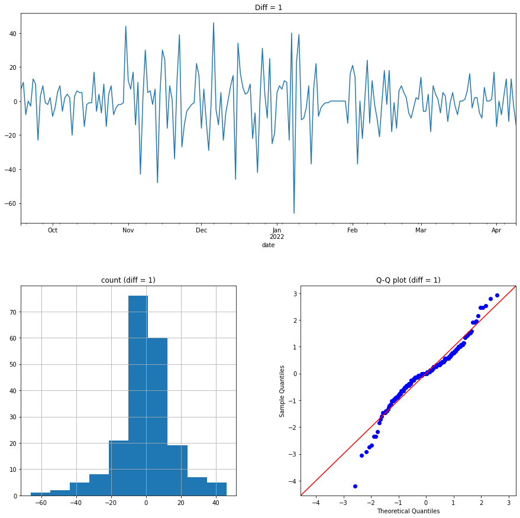

```python
# Lag=1 ábrák
fig = plt.figure(figsize=(15,15))
ax1 = plt.subplot(211)
ddf.plot(ax=ax1, legend=False, title="Diff = 1")

ax2 = plt.subplot(223)
ddf.hist(ax=ax2)
ax2.set_title("count (diff = 1)")

ax3 = plt.subplot(224)
sm.qqplot(ddf["count"], fit=True, line="45", ax=ax3)
ax3.set_title("Q-Q plot (diff = 1)")
plt.show()
```

Az idősor ábrája alapján a -1-szeres lag-gel differenciált adatok stacionáriusnak tekintehtők. A histogram és a q-q plot is jobban megközelítik a normalitásra jellemző alakzatot - igaz a q-q plot esetén ez csak a széleket leszámítva érvényesül.

```python
# Augmented Dickey–Fuller test
adf = adfuller(ddf, maxlag=1)
print("ADF teszt statisztika: ", round(adf[0],3))
print("ADF p-érték : ", round(adf[1], 5))
print("ADF kritikus értékek : ", {k: round(v, 3) for k, v in adf[4].items()})
```

```
ADF teszt statisztika:  -13.863
ADF p-érték :  0.0
ADF kritikus értékek :  {'1%': -3.463, '5%': -2.876, '10%': -2.574}
```

Az ADF teszt becsült p-értéke 5 tizedesjegyre kerekítve 0, valamint a kritikus értékek szerint α=0.01 mellett is szignifikáns a tesztstatisztika. Ez megerősíti a korábbi feltevést, mely szerint stacionárius a differenciált idősor.

### ARIMA modell

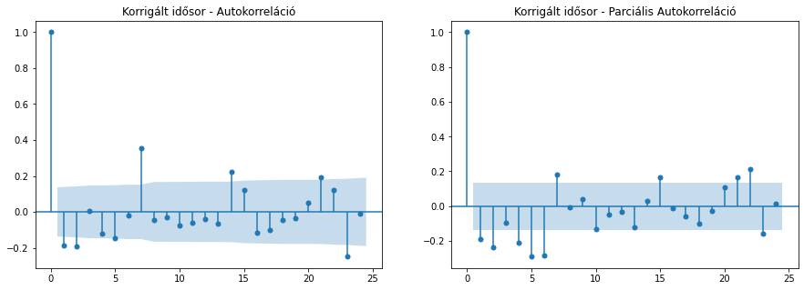

```python
# Korrelogrammok - lag=1
fig, axes = plt.subplots(1,2, figsize=(15,5))

tsaplots.plot_acf(ddf, ax=axes[0], title="Korrigált idősor - Autokorreláció")
tsaplots.plot_pacf(ddf, ax=axes[1], title="Korrigált idősor - Parciális Autokorreláció")
plt.show()
```

A korrelogrammok alapján szóba jöhető ARIMA modellek:

- 2 <= p <= 7
- i = 1
- q = 2

```python
# R^2 függvény
def r_squared(y, y_hat):
    y_bar = y.mean()
    ss_tot = ((y-y_bar)**2).sum()
    ss_res = ((y-y_hat)**2).sum()
    return 1 - (ss_res/ss_tot)
```

```python
# Inkonzervatív baseline modell
from statsmodels.tsa.arima.model import ARIMA
model = ARIMA(df, order=(7,1,2))

fitted = model.fit()
aic = round(fitted.aic, 3)
bic = round(fitted.bic, 3)
ljungbox = sm.stats.acorr_ljungbox(df, lags=[1], return_df=True)
ljungbox_p = round(float(ljungbox["lb_pvalue"]), 5)
r_s= round(r_squared(df["count"], fitted.predict()), 3)

print("AIC: ", aic)
print("BIC: ", bic)
print("Ljung-Box p-érték: ", ljungbox_p)
print("R^2: ", r_s)
```

```
AIC:  1655.147
BIC:  1688.329
Ljung-Box p-érték:  0.0
R^2:  0.727
```

```python
# p hiperparaméter módosítása
for p in range(2, 7):
    print("p = ", p)
    model = ARIMA(df, order=(p,1,2))
    fitted = model.fit()
    _aic = round(fitted.aic, 3)
    _bic = round(fitted.bic, 3)
    _ljungbox = sm.stats.acorr_ljungbox(df, lags=[1], return_df=True)
    _ljungbox_p = round(float(_ljungbox["lb_pvalue"]), 5)
    _r_s= round(r_squared(df["count"], fitted.predict()), 3)

    print("AIC: ", _aic)
    print("BIC: ", _bic)
    print("R^2: ", _r_s)
    print()
```

```
p =  2
AIC:  1670.874
BIC:  1687.465
R^2:  0.689

p =  3
AIC:  1672.661
BIC:  1692.57
R^2:  0.69

p =  4
AIC:  1672.327
BIC:  1695.554
R^2:  0.693

p =  5
AIC:  1655.754
BIC:  1682.299
R^2:  0.721

p =  6
AIC:  1653.509
BIC:  1683.372
R^2:  0.726
```

```python
# Végső modell
model = ARIMA(df, order=(6,1,2))

fitted = model.fit()
aic = round(fitted.aic, 3)
bic = round(fitted.bic, 3)
ljungbox = sm.stats.acorr_ljungbox(df, lags=[1], return_df=True)
ljungbox_p = round(float(ljungbox["lb_pvalue"]), 5)
r_s= round(r_squared(df["count"], fitted.predict()), 3)

print("AIC: ", aic)
print("BIC: ", bic)
print("Ljung-Box p-érték: ", ljungbox_p)
print("R^2: ", r_s)
```

```
AIC:  1653.509
BIC:  1683.372
Ljung-Box p-érték:  0.0
R^2:  0.726
```

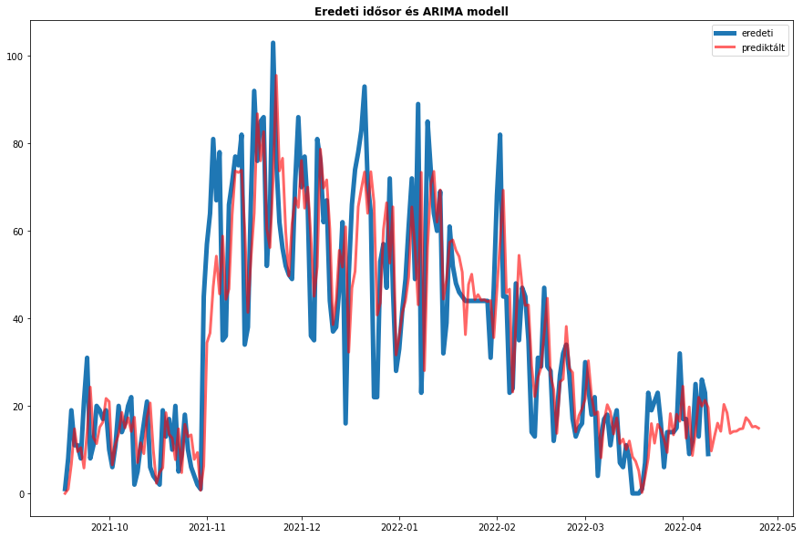

```python
# ARIMA által becsült idősor
plt.figure(figsize=figsize)
plt.plot(df, linewidth=5, label="eredeti")
plt.plot(fitted.predict(end=220), color="red", linewidth=3, alpha=0.6, label="prediktált")
plt.legend()
plt.title("Eredeti idősor és ARIMA modell", fontdict={"size":12, "weight":"bold"})
plt.show()
```

### Idősorok összehasonlítása

https://github.com/owid/covid-19-data/tree/master/public/data/hospitalizations

```python
# Adatok szűrése
hosp = pd.read_csv("covid-hospitalizations.csv")
hosp = hosp.loc[(hosp["entity"] == "Hungary") &
                (hosp["indicator"] == "Daily hospital occupancy per million"),
                ["date", "value"]].reset_index(drop=True)

start = "2021-09-17"
end = "2022-04-09"
s = np.where(hosp["date"] == start)[0][0]
e = np.where(hosp["date"] == end)[0][0]
hosp = hosp.loc[s:e, :]
hosp["date"] = pd.date_range(start, end)
hosp.index = hosp["date"]
hosp.drop("date", axis=1, inplace=True)
hosp
```

| date | value |
| --- | --- |
| 2021-09-17 | 36.640 |
| 2021-09-18 | 36.640 |
| 2021-09-19 | 36.640 |
| 2021-09-20 | 39.443 |
| 2021-09-21 | 41.623 |
| ... | ... |
| 2022-04-05 | 190.260 |
| 2022-04-06 | 185.278 |
| 2022-04-07 | 178.947 |
| 2022-04-08 | 175.210 |
| 2022-04-09 | 175.210 |

205 rows × 1 columns

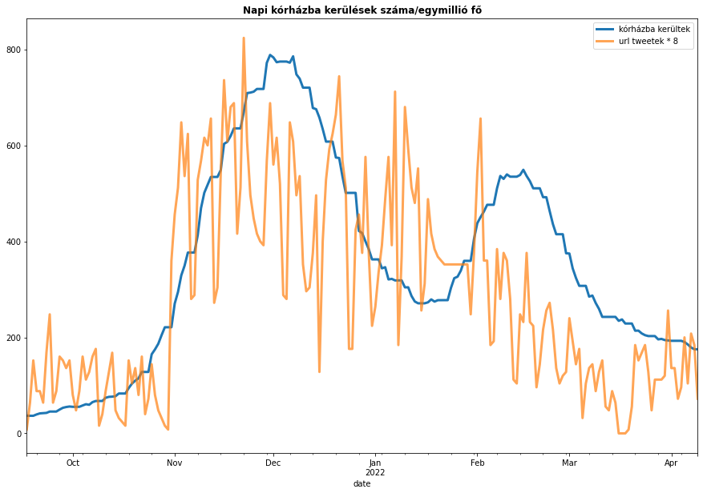

```python
# Új idősor ábrázolása
hosp.plot(figsize=figsize, linewidth=3)
plt.plot(df["count"]*8, linewidth=3, alpha=0.7)
plt.title("Napi kórházba kerülések száma/egymillió fő", fontdict={"size":12, "weight":"bold"})
plt.legend(["kórházba kerültek","url tweetek * 8"])
plt.show()
```

```python
# Pearson korreláció
from scipy.stats import pearsonr

corr = pearsonr(df["count"], hosp["value"])
print("Pearson r: ", round(corr[0],3))
print("Pearson r p-érték: ", corr[1])
```

```
Pearson r:  0.653
Pearson r p-érték:  2.545828984176355e-26
```

```python
dfu = df.copy()
dfu["hosp"] = hosp["value"]
dfu
```

| date | count | hosp |
| --- | --- | --- |
| 2021-09-17 | 1.0 | 36.640 |
| 2021-09-18 | 8.0 | 36.640 |
| 2021-09-19 | 19.0 | 36.640 |
| 2021-09-20 | 11.0 | 39.443 |
| 2021-09-21 | 11.0 | 41.623 |
| ... | ... | ... |
| 2022-04-05 | 25.0 | 190.260 |
| 2022-04-06 | 13.0 | 185.278 |
| 2022-04-07 | 26.0 | 178.947 |
| 2022-04-08 | 23.0 | 175.210 |
| 2022-04-09 | 9.0 | 175.210 |

205 rows × 2 columns

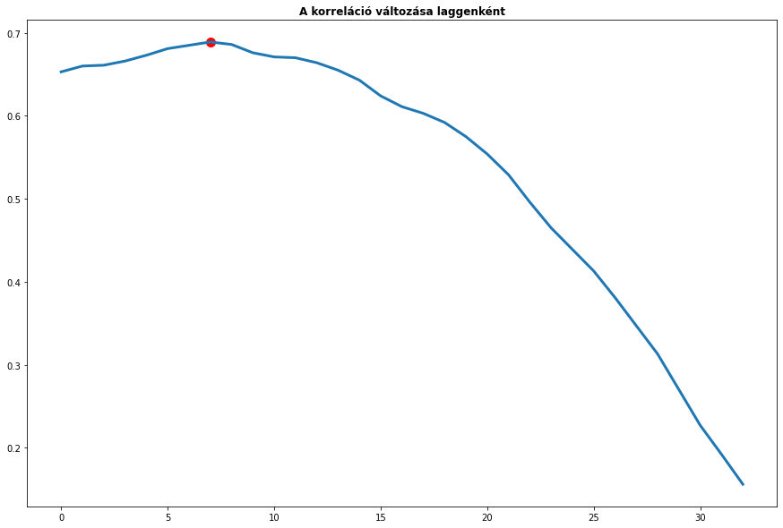

```
Maximum r:  0.689
Maximum r p-érték:  3.555574129744326e-29
lag:  7
```

```python
# Shiftelt korrelációk
corrs = {}
for i in range(0, len(dfu)):
    _df = dfu.copy()
    _df["hosp"] = _df["hosp"].shift(-i)
    _df.dropna(inplace=True)
    corr = pearsonr(_df["count"], _df["hosp"])
    if corr[1] < 0.05:
        corrs[round(corr[0],3)] = corr[1]
    else:
        break

max_corr = max(list(corrs.keys()))
lag = list(corrs.keys()).index(max_corr)

corrline = list(corrs.keys())
plt.figure(figsize=figsize)
plt.plot(corrline, linewidth=3)
plt.scatter(lag, max_corr, color="red", s=100)
plt.title("A korreláció változása laggenként", fontdict={"size":12, "weight":"bold"})
plt.show()

print("Maximum r: ", max_corr)
print("Maximum r p-érték: ", corrs[max_corr])
print("lag: ", lag)
```

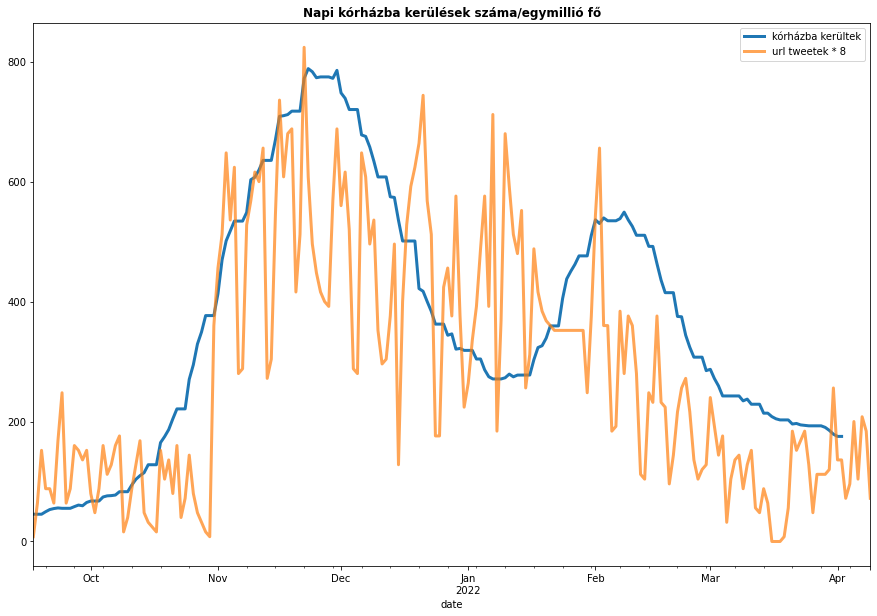

```python
# Shiftelt idősor
hosp.shift(-7).plot(figsize=figsize, linewidth=3)
plt.plot(df["count"]*8, linewidth=3, alpha=0.7)
plt.title("Napi kórházba kerülések száma/egymillió fő", fontdict={"size":12, "weight":"bold"})
plt.legend(["kórházba kerültek","url tweetek * 8"])
plt.show()
```

### Felhasznált idordalom

- Huo, Jinsheng & Cox, Chris & Seaver, William & Robinson, R. & Jiang, Yan. (2010). Application of Two-Directional Time Series Models to Replace Missing Data. Journal of Environmental Engineering